# Instrumentos de Análisis Urbano II: Trabajo Final

Marina Santamaria

2022-11-11

# **“Impacto del cambio en los usos de suelo, en el incremento de los niveles de emisión de GEI en la Argentina”**

### Argentina ha perdido forestación autóctona en pos de favorecer desarrollos urbanos, proyecciones industriales y en particular, el emplazamiento de cultivos y ganado. Si bien en el país existe un marco normativo para la preservación de los bosques nativos, la regulación de las respectivas leyes resulta insuficiente. Los cambios de uso de suelo para posibilitar la producción agrícola-ganadera, representan la segunda fuente más importante de emisiones del país después del consumo de energía, lo que sumado a la ausencia de regulación complejiza la situación.

**GITHUB**

*Creo el proyecto TPF_IAU2, que vinculo al repositorio generado desde GITHUB. Abro un nuevo archivo desde R Markdown que guardo en el proyecto de referencia.*

**RMarkdown**

*Cargo las librerías a utilizar.*

```r
library(tidyverse)
library(skimr)
library(tibble)
library(tidyr)
library(dplyr)
```

**CARGA DE DATOS**

#### Las emisiones de gases de efecto invernadero (GEI) se generan tanto de la explotación agrícola ganadera, como de las emisiones de CO2 causadas por la conversión de los ecosistemas, en su mayoría tierras forestales y naturales, al uso agrícola de las mismas.

#### Analizo las emisiones de GEI originadas por la producción agrícola y de actividades asociadas al uso de la tierra a nivel mundial.

*Descargo la base de datos sobre las emisiones de GEI, del sitio web de la Organización para la Agricultura y la Alimentación (FAO). Fuente:https://www.fao.org/faostat/es/#data)*

```r
gei_global<-read.csv(file ="DATA/FAOSTAT_data_en_emissions.csv",
                         stringsAsFactors = TRUE,
                  encoding = "UTF-8")
```

*Reviso el resumen de la información estadística de las variables del data frame.*

```r
skim(gei_global)
```

Data summary

| Name | gei_global |
| --- | --- |
| Number of rows | 1048575 |
| Number of columns | 17 |
| _______________________ |  |
| Column type frequency: |  |
| factor | 9 |
| numeric | 8 |
| ________________________ |  |
| Group variables | None |

**Variable type: factor**

| skim_variable | n_missing | complete_rate | ordered | n_unique | top_counts |
| --- | --- | --- | --- | --- | --- |
| Domain.Code | 0 | 1 | FALSE | 2 | emp: 970033, GT: 78542 |
| Domain | 0 | 1 | FALSE | 2 | emp: 970033, Emi: 78542 |
| Area | 0 | 1 | FALSE | 188 | emp: 970033, Aus: 1918, Uni: 1887, Fra: 1794 |
| Element | 0 | 1 | FALSE | 9 | emp: 970033, Emi: 21042, Emi: 13966, Emi: 12331 |
| Item | 0 | 1 | FALSE | 20 | emp: 970033, IPC: 11796, Man: 9397, Agr: 8393 |
| Source | 0 | 1 | FALSE | 2 | emp: 970033, UNF: 78542 |
| Unit | 0 | 1 | FALSE | 2 | emp: 970033, kil: 78542 |
| Flag.Description | 0 | 1 | FALSE | 3 | emp: 970033, Off: 41799, Est: 36743 |
| Note | 0 | 1 | FALSE | 3 | emp: 1033203, NC/: 11875, UNF: 3497 |

**Variable type: numeric**

| skim_variable | n_missing | complete_rate | mean | sd | p0 | p25 | p50 | p75 | p100 | hist |
| --- | --- | --- | --- | --- | --- | --- | --- | --- | --- | --- |
| Area.Code..M49. | 970033 | 0.07 | 425.18 | 241.43 | 4 | 231.00 | 398.00 | 620.00 | 894 | ▆▇▇▆▆ |
| Element.Code | 970033 | 0.07 | 387220.38 | 357587.32 | 7225 | 7230.00 | 723113.00 | 724313.00 | 724413 | ▇▁▁▁▇ |
| Item.Code | 970033 | 0.07 | 6810.39 | 13018.25 | 1707 | 1711.00 | 5059.00 | 5064.00 | 67292 | ▇▁▁▁▁ |
| Year.Code | 970033 | 0.07 | 2004.59 | 8.54 | 1990 | 1997.00 | 2004.00 | 2012.00 | 2020 | ▇▇▇▇▆ |
| Year | 970033 | 0.07 | 2004.59 | 8.54 | 1990 | 1997.00 | 2004.00 | 2012.00 | 2020 | ▇▇▇▇▆ |
| Source.Code | 970033 | 0.07 | 3051.00 | 0.00 | 3051 | 3051.00 | 3051.00 | 3051.00 | 3051 | ▁▁▇▁▁ |
| Value | 970155 | 0.07 | 3964.04 | 563591.62 | -11288401 | 2.03 | 57.28 | 1202.54 | 155429967 | ▇▁▁▁▁ |
| ValueA | 970033 | 0.07 | 12017.12 | 97071.00 | 0 | 5.48 | 152.80 | 2227.06 | 11288401 | ▇▁▁▁▁ |

```r
class(gei_global)
```

```
## [1] "data.frame"
```

```r
typeof(gei_global)
```

```
## [1] "list"
```

```r
str(gei_global)
```

```
## 'data.frame':    1048575 obs. of  17 variables:
##  $ Domain.Code     : Factor w/ 2 levels "","GT": 2 2 2 2 2 2 2 2 2 2 ...
##  $ Domain          : Factor w/ 2 levels "","Emissions Totals": 2 2 2 2 2 2 2 2 2 2 ...
##  $ Area.Code..M49. : int  4 4 4 4 4 4 4 4 4 4 ...
##  $ Area            : Factor w/ 188 levels "","Afghanistan",..: 2 2 2 2 2 2 2 2 2 2 ...
##  $ Element.Code    : int  7225 7230 724413 724313 723113 7225 724413 723113 7225 724413 ...
##  $ Element         : Factor w/ 9 levels "","Direct emissions (N2O)",..: 3 8 6 7 5 3 6 5 3 6 ...
##  $ Item.Code       : int  5066 5066 5066 5066 5066 5066 5066 5066 5058 5058 ...
##  $ Item            : Factor w/ 20 levels "","Agricultural Soils",..: 3 3 3 3 3 3 3 3 8 8 ...
##  $ Year.Code       : int  2005 2005 2005 2005 2005 2013 2013 2013 2005 2005 ...
##  $ Year            : int  2005 2005 2005 2005 2005 2013 2013 2013 2005 2005 ...
##  $ Source.Code     : int  3051 3051 3051 3051 3051 3051 3051 3051 3051 3051 ...
##  $ Source          : Factor w/ 2 levels "","UNFCCC": 2 2 2 2 2 2 2 2 2 2 ...
##  $ Unit            : Factor w/ 2 levels "","kilotonnes": 2 2 2 2 2 2 2 2 2 2 ...
##  $ Value           : num  10.07 0.021 281.96 5.565 287.525 ...
##  $ ValueA          : num  10.07 0.021 281.96 5.565 287.525 ...
##  $ Flag.Description: Factor w/ 3 levels "","Estimated value",..: 3 3 2 2 2 3 2 2 3 2 ...
##  $ Note            : Factor w/ 3 levels "","NC/CRF/BUR",..: 1 1 1 1 1 1 1 1 1 1 ...
```

**ORDENAR Y PROCESAR DATOS**

*Selecciono las variables de interés para analizar la información.*

```r
gei_global_1 <- gei_global%>%
select(Area,Element,Item,Year,ValueA)%>%
drop_na()
```

*Renombro las variables.*

```r
gei_global_2 <- gei_global_1%>%
rename(Pais="Area",Tipo_de_Emision="Element",Origen="Item",Año="Year",KToneladas_CO2="ValueA")
```

*Calculo las cantidades totales de emisiones por año.*

```r
gei_global_3 <- gei_global_2%>%
group_by(Pais,Año) %>%
summarise(Total_KT_CO2=sum(KToneladas_CO2, na.rm = TRUE))
str(gei_global_3)
```

[output not shown]

[output cut: 54 more lines]

[output not shown]

*Pivoteo los datos de largo a ancho.*

```r
gei_global_4 <- gei_global_3 %>%
pivot_wider(names_from ="Año", values_from ="Total_KT_CO2")
```

*Obtengo el promedio de las emisiones por año.*

```r
gei_promedio_global <- gei_global_4 %>%
mutate(Promedio = rowMeans(across(where(is.numeric)),
        na.rm = TRUE))%>%
mutate(Promedio_Round=round(Promedio, digits =2 ))
```

*Obtengo los primeros 20 países, con los promedios de emisión más altos.*

```r
gei_20_paises <- gei_promedio_global %>%
select(Pais:Promedio_Round)%>%
group_by(Promedio_Round)%>%
arrange(desc(Promedio_Round)) %>%
head(20)
```

**GRÁFICOS**

*Represento los resultados obtenidos a través de un gráfico de puntos.*

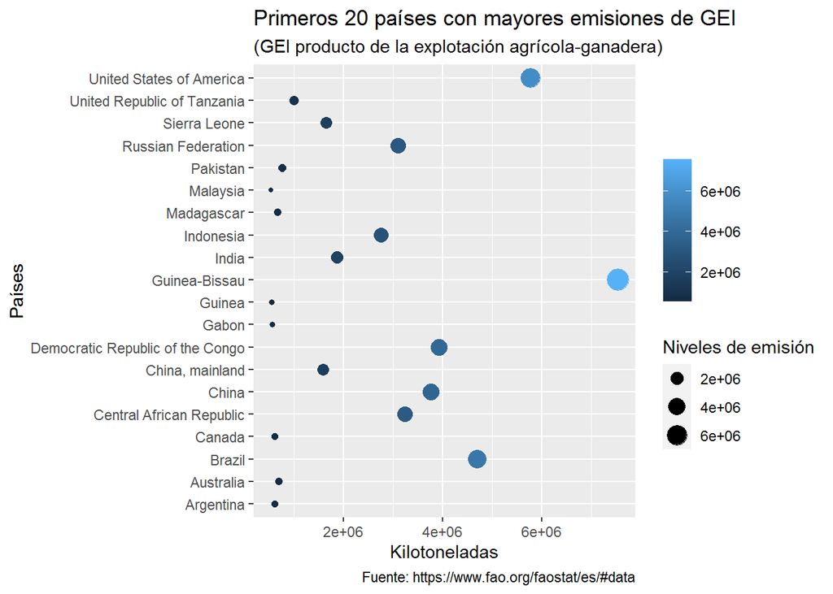

```r
ggplot(gei_20_paises)+
geom_point(aes(x = Pais, y = Promedio_Round, size = Promedio_Round, color= Promedio_Round))+
coord_flip()+
labs(title = "Primeros 20 países con mayores emisiones de GEI", subtitle = "(GEI producto de la explotación agrícola-ganadera)",
caption="Fuente: https://www.fao.org/faostat/es/#data",x="Países", y = "Kilotoneladas",size="Niveles de emisión", color="")
```

[figure not shown]

```r
ggplot(gei_global_3)+
geom_bar(aes(x=factor(Año), fill=Total_KT_CO2), fill ="cornflowerblue", bins=30)+
labs(title = "Promedio de emisiones de GEI por año", subtitle = "Período:1990-2020",
caption="Fuente: https://www.fao.org/faostat/es/#data",x="Años", y = "Kilotoneladas", color="Promedios")+
theme(axis.text.x = element_text(angle = 90, hjust = 1),plot.margin = margin(0.25, 1, 0.25, 0.1, "cm"))
```

**MAPEO**

*Cargo las librerías a utilizar.*

```r
library(sf)
library(car)
```

```r
library(mapdata)
library(maps)
library(ggmap)
library(ggrepel)
library(ggplot2)
library(viridis)
```

*Descargo un mapa del mundo en formato geojson, para volcar los datos analizados.*

```r
map_mundo <- st_read("DATA/countries.geojson")
head(map_mundo)
```

```
## Simple feature collection with 6 features and 2 fields
## Geometry type: MULTIPOLYGON
## Dimension:     XY
## Bounding box:  xmin: -70.06241 ymin: -18.0314 xmax: 74.89231 ymax: 60.48078
## Geodetic CRS:  WGS 84
##         ADMIN ISO_A3                       geometry
## 1       Aruba    ABW MULTIPOLYGON (((-69.99694 1...
## 2 Afghanistan    AFG MULTIPOLYGON (((71.0498 38....
## 3      Angola    AGO MULTIPOLYGON (((11.73752 -1...
## 4    Anguilla    AIA MULTIPOLYGON (((-63.03767 1...
## 5     Albania    ALB MULTIPOLYGON (((19.74777 42...
## 6       Aland    ALA MULTIPOLYGON (((20.92018 59...
```

*Para poder vincular la información espacial con el data frame trabajado, renombro la variable ADMIN y recodifico los nombres de los países que presentan diferencias con respecto a los datos geoespaciales.*

```r
map_mundo_ <- map_mundo %>%
rename(Pais = "ADMIN")
```

```r
gei_global_5<-gei_promedio_global %>%
select(Pais,Promedio_Round) %>%
mutate(Pais=fct_recode(Pais,"Russia"="Russian Federation","Bolivia"="Bolivia (Plurinational State of)","Venezuela"="Venezuela (Bolivarian Republic of)","Iran"="Iran (Islamic Republic of)","United Kingdom"="United Kingdom of Great Britain and Northern Ireland"))
```

*Vinculo la información geoespacial con el data frame trabajado.*

```r
gei_map_mundo <- left_join(map_mundo_, gei_global_5, by = "Pais")
```

*Realizo un mapa coroplético para representar cartográficamente el promedio de emisiones de GEI a nivel mundial.*

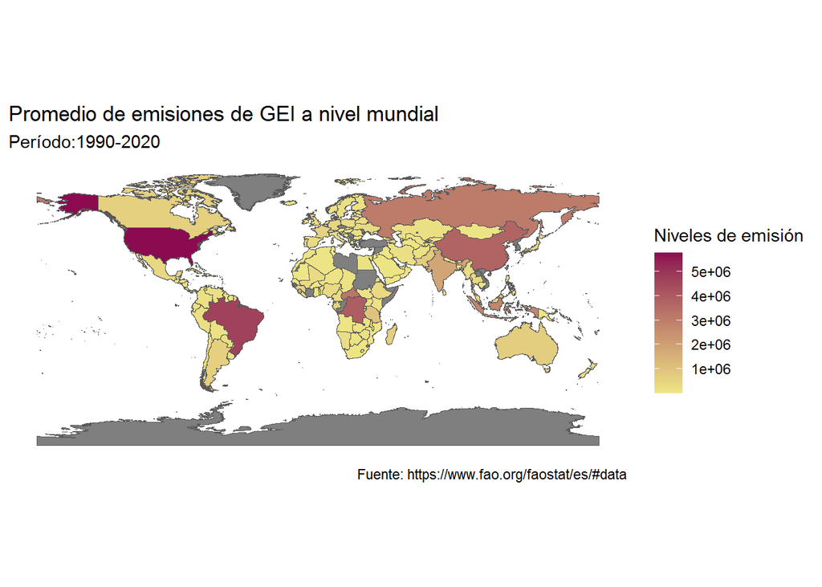

```r
ggplot()+
geom_sf(data = gei_map_mundo, aes(fill=Promedio_Round))+
scale_fill_gradient(low="khaki2", high="deeppink4")+
theme_minimal() +
coord_sf(datum = NA)+
labs(title = "Promedio de emisiones de GEI a nivel mundial", subtitle = "Período:1990-2020",
caption="Fuente: https://www.fao.org/faostat/es/#data", fill="Niveles de emisión")
```

### Analizo las emisiones de GEI originadas por la producción agrícola y de actividades asociadas al uso de la tierra a nivel regional (América del Sur).

*Descargo la base de datos sobre las emisiones de GEI correspondinte a la región de América de Sur, del sitio web de la Organización para la Agricultura y la Alimentación (FAO).Fuente:https://www.fao.org/faostat/es/#data)*

```r
gei_asur<-read.csv(file ="DATA/FAOSTAT_data_es_emisiones_alyc.csv",
                         stringsAsFactors = TRUE,
                  encoding = "UTF-8")
```

*Reviso el resumen de la información estadística de las variables del data frame.*

```r
skim(gei_asur)
```

Data summary

| Name | gei_asur |
| --- | --- |
| Number of rows | 46890 |
| Number of columns | 17 |
| _______________________ |  |
| Column type frequency: |  |
| factor | 9 |
| logical | 1 |
| numeric | 7 |
| ________________________ |  |
| Group variables | None |

**Variable type: factor**

| skim_variable | n_missing | complete_rate | ordered | n_unique | top_counts |
| --- | --- | --- | --- | --- | --- |
| X.U.FEFF.Código.Ámbito | 0 | 1 | FALSE | 1 | GT: 46890 |
| Ámbito | 0 | 1 | FALSE | 1 | Tot: 46890 |
| Área | 0 | 1 | FALSE | 14 | Arg: 3450, Bol: 3450, Bra: 3450, Chi: 3450 |
| Elemento | 0 | 1 | FALSE | 8 | Emi: 10230, Emi: 7350, Emi: 7350, Emi: 6180 |
| Producto | 0 | 1 | FALSE | 25 | Far: 3300, IPC: 2880, AFO: 2520, Cam: 2520 |
| Fuente | 0 | 1 | FALSE | 1 | FAO: 46890 |
| Unidad | 0 | 1 | FALSE | 1 | mil: 46890 |
| Símbolo | 0 | 1 | FALSE | 1 | E: 46890 |
| Descripción.del.Símbolo | 0 | 1 | FALSE | 1 | Val: 46890 |

**Variable type: logical**

| skim_variable | n_missing | complete_rate | mean | count |
| --- | --- | --- | --- | --- |
| Nota | 46890 | 0 | NaN | : |

**Variable type: numeric**

| skim_variable | n_missing | complete_rate | mean | sd | p0 | p25 | p50 | p75 | p100 | hist |
| --- | --- | --- | --- | --- | --- | --- | --- | --- | --- | --- |
| Código.área..M49. | 0 | 1 | 375.39 | 291.21 | 32.0 | 152.00 | 254.00 | 604.00 | 862 | ▇▆▁▃▅ |
| Código.Elemento | 0 | 1 | 370343.90 | 358264.10 | 7225.0 | 7230.00 | 723113.00 | 724313.00 | 724413 | ▇▁▁▁▇ |
| Código.Producto | 0 | 1 | 11047.04 | 18146.87 | 1707.0 | 5060.00 | 6516.00 | 6994.00 | 69921 | ▇▁▁▁▁ |
| Código.año | 0 | 1 | 2004.50 | 8.66 | 1990.0 | 1997.00 | 2004.50 | 2012.00 | 2019 | ▇▇▇▇▇ |
| Año | 0 | 1 | 2004.50 | 8.66 | 1990.0 | 1997.00 | 2004.50 | 2012.00 | 2019 | ▇▇▇▇▇ |
| Código.fuente | 0 | 1 | 3050.00 | 0.00 | 3050.0 | 3050.00 | 3050.00 | 3050.00 | 3050 | ▁▁▇▁▁ |
| Valor | 0 | 1 | 15414.69 | 107700.38 | -519221.8 | 0.71 | 31.31 | 1143.44 | 2164453 | ▇▁▁▁▁ |

*Selecciono las variables de interés para analizar la información.*

```r
gei_asur_1 <- gei_asur%>%
select(Área,Elemento,Producto,Año,Valor)%>%
drop_na()
```

*Renombro las variables seleccionadas para procesar los datos.*

```r
gei_asur_2<- gei_asur_1%>%
rename(Pais="Área",Tipo_de_Emision="Elemento",Origen="Producto",KToneladas_CO2="Valor")%>%
mutate(Pais = fct_recode(Pais,"Venezuela"="Venezuela (República Bolivariana de)", "Bolivia"="Bolivia (Estado Plurinacional de)","Islas Malvinas"="Islas Malvinas (Falkland Islands)"))
```

*Obtengo el total de emisiones por país y por año.*

```r
gei_asur_3<-gei_asur_2%>%
group_by(Pais,Año) %>%
summarise(Total_KT_CO2=sum(KToneladas_CO2, na.rm = TRUE))%>%
mutate(Total_KT_CO2_Round=round(Total_KT_CO2,digits =1))
```

*Represento el total de emisiones registradas en la región de America del Sur.*

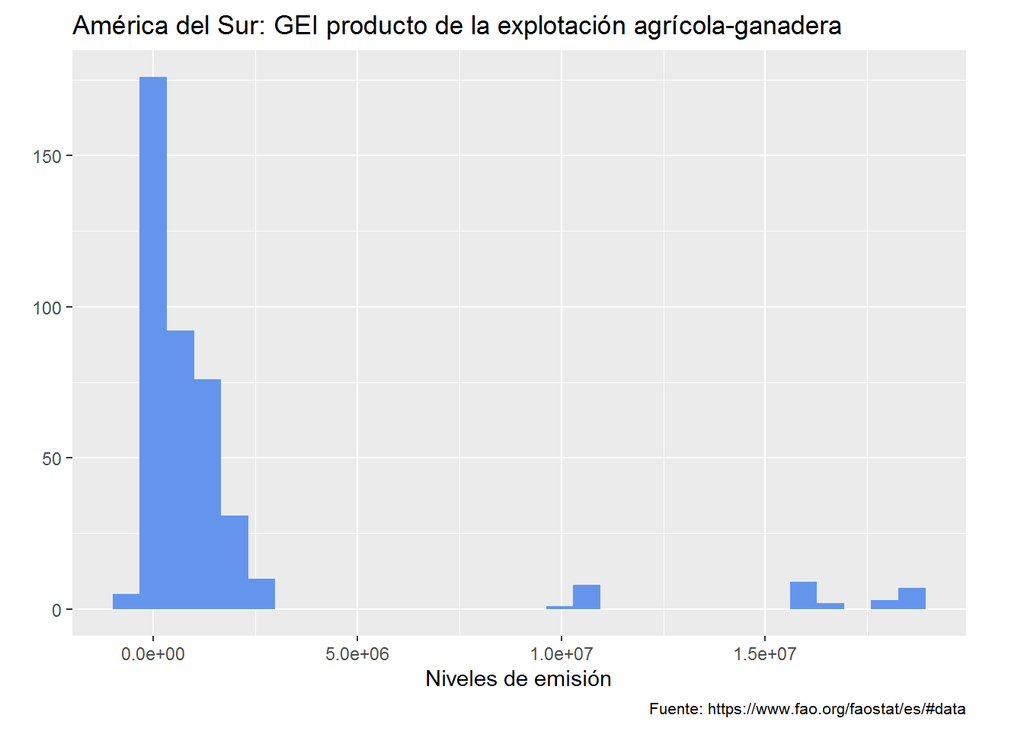

```r
ggplot(gei_asur_3)+
geom_histogram(aes(x =Total_KT_CO2),fill= "cornflowerblue",bins = 30)+
labs(title = "América del Sur: GEI producto de la explotación agrícola-ganadera ", caption="Fuente: https://www.fao.org/faostat/es/#data", x = "Niveles de emisión", y ="")+
theme(plot.margin = margin(0.25, 1, 0.25, 0.1, "cm"),plot.caption=element_text(size=8))
```

*Represento el total de emisiones por país.*

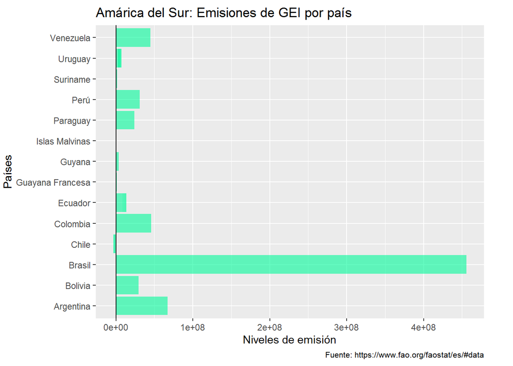

```r
ggplot(gei_asur_3)+
geom_col(aes(x = Pais, y = Total_KT_CO2), fill = "mediumspringgreen", alpha = 0.6) +
geom_hline(yintercept = 0)+
coord_flip() +
labs(title = "Amárica del Sur: Emisiones de GEI por país", caption="Fuente: https://www.fao.org/faostat/es/#data", fill="Niveles de emisión", x ="Países", y ="Niveles de emisión")+
theme(plot.margin = margin(0.25, 1, 0.25, 0.1, "cm"),plot.caption=element_text(size=8))
```

*Represento el total de emisiones durante el período de 1990-2019, diferenciado por país.*

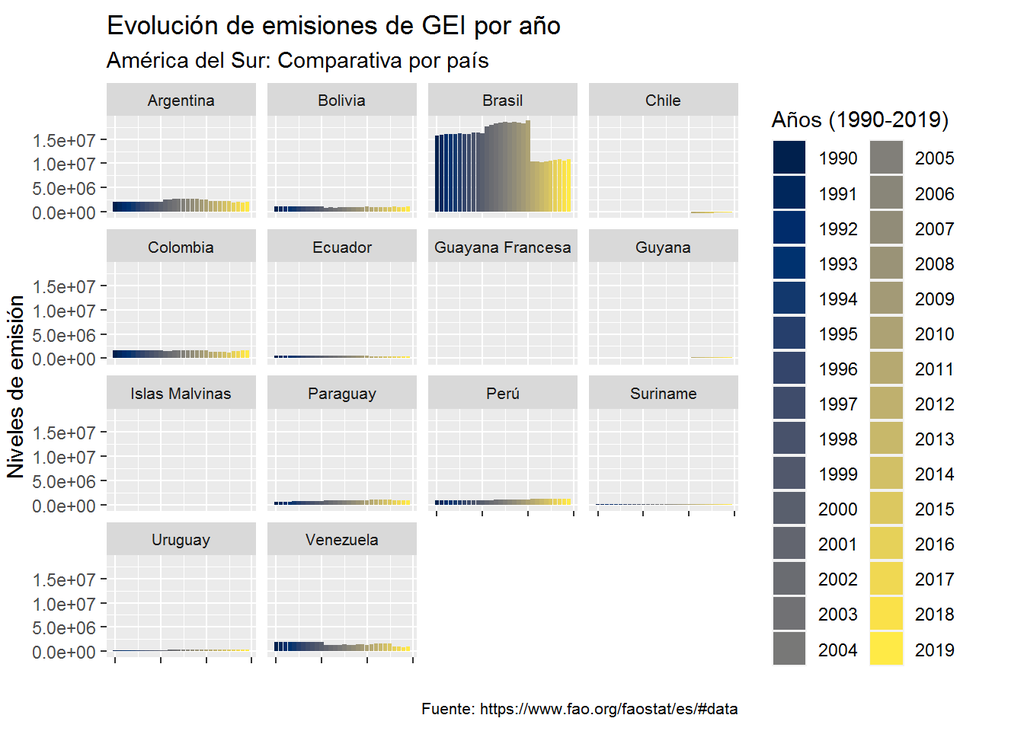

```r
ggplot(gei_asur_3)+
geom_col(aes(x = Año, y = Total_KT_CO2, fill= factor(Año)))+
scale_fill_viridis_d(option="cividis")+
theme(axis.text.x = element_blank())+
facet_wrap(~Pais)+
labs(title = "Evolución de emisiones de GEI por año",
subtitle = "América del Sur: Comparativa por país",
caption ="Fuente: https://www.fao.org/faostat/es/#data", x = "", y = "Niveles de emisión",
fill= "Años (1990-2019)")+
theme(strip.text.x = element_text(size = 8),plot.margin = margin(0.25, 1, 0.25, 0.1, "cm"),plot.caption=element_text(size=8))
```

```r
gei_asur_4 <- gei_asur_3%>%
filter(Pais%in% c("Argentina","Brasil","Chile","Bolivia","Colombia","Ecuador","Paraguay","Peru","Uruguay","Venezuela") & Año >= 1995)
```

*Represento el total de emisiones por país.*

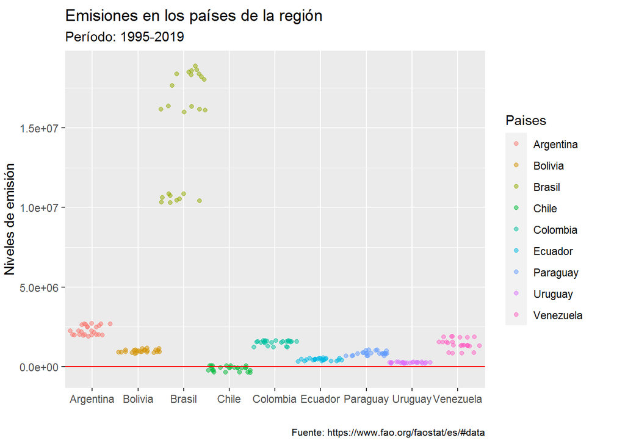

```r
ggplot(gei_asur_4) +
geom_jitter(aes(x = Pais, y = Total_KT_CO2, color= Pais), width = .5,alpha = .5) +
geom_hline(yintercept = 0, col = "red") +
labs(title = "Emisiones en los países de la región",
subtitle = "Período: 1995-2019",
caption ="Fuente: https://www.fao.org/faostat/es/#data", x = "", y = "Niveles de emisión",
fill= "Países", color="Paises")+
theme(plot.margin = margin(0.25, 1, 0.25, 0.1, "cm"), plot.caption=element_text(size=8))
```

*Represento el total de emisiones por año de cada país de la región.*

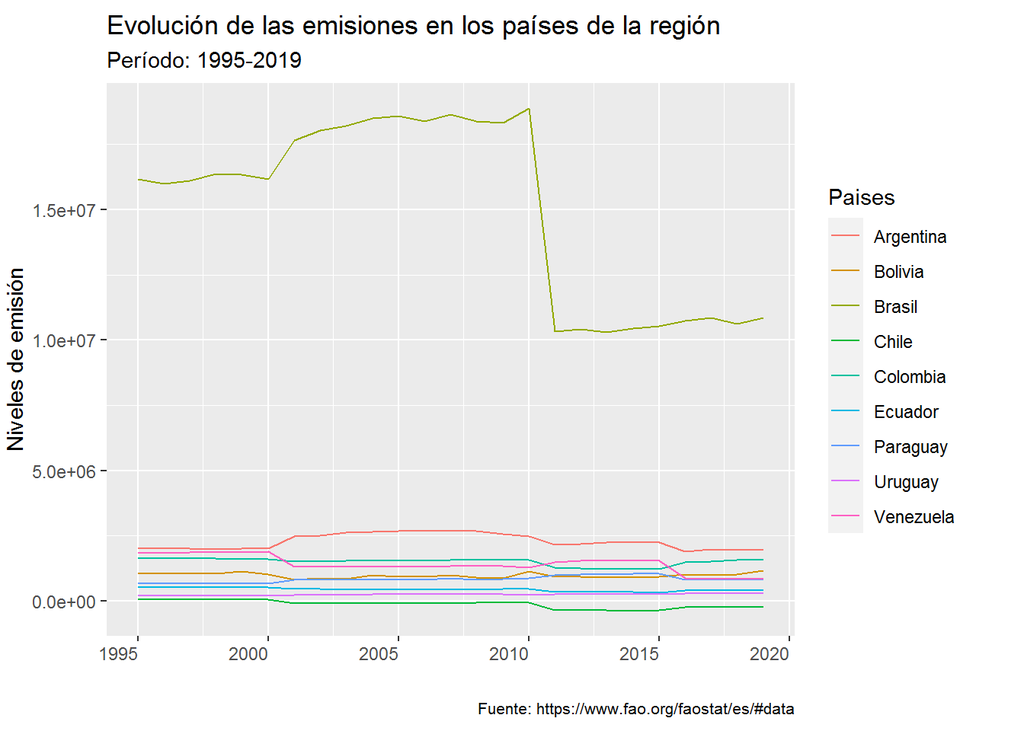

```r
ggplot(gei_asur_4,aes(x=Año, y=Total_KT_CO2, color=Pais, group =Pais))+
geom_line()+
theme(axis.text.x = element_text(angle = 0, hjust = 1))+
labs(title = "Evolución de las emisiones en los países de la región",
subtitle = "Período: 1995-2019",
caption ="Fuente: https://www.fao.org/faostat/es/#data", x = "", y = "Niveles de emisión",
fill= "Países", color="Paises")+
theme(plot.margin = margin(0.25, 1, 0.25, 0.1, "cm"),plot.caption=element_text(size=8))
```

```r
library(dplyr)
library(tidyr)
```